# ANOVA

```r
# Set working directory
library(car)
library(emmeans)
library(rstatix)
library(tidyverse)
library(ggpubr)

options(max.print = 1e+05)
```

## Introducción ANOVA

Uno de los procesos más usados para comparar diferentes “tratamientos” sobre un grupo experimental es sin duda el Análisis de Varianza (ANOVA). Desarrollado originalmente por R.A. Fisher y ha tenido una gran influencia en la estadística. El análisis de varianza se usa principalmente para dos propósitos: 1) para estimar y desarrollar prueba de hipótesis de varianzas de una población. 2) Estimar y probar medias poblacionales. En esta introducción resolveremos ejemplos para la estimación de medias poblacionales.

## ANOVA Modelos de una via (One-Way ANOVA)

Carne proveniente de caza, entre otras aquellas del venado de cola-blanca, y ardilla gris, son usadas como alimento por familias, cazadores y otros individuos por razones culturales, personales, o de salud. En un estudio de Holben et al. estimó el contenido de selenio de carne de venado cola-blanca libre (venison), y ardilla gris (squirrel) obtenidos de una región de baja concentración de selenio en EEUU. Estos contenidos de selenio fueron también comparados con concentraciones de carne de ganado producido en la misma región (RRB) y en una región externa (NRRB). Nos interesa saber si la concentración de selenio $(\mu g/100g)$ es distinta en los grupos de carne. (EXA_C08_S02_01.csv).

La hipótesis nula $H_0$ de este modelo es que todos los promedios poblacionales (cada promedio de la población de cada caso) son iguales entre ellos $\mu_1 = \mu_2 = \mu_3 \dots = \mu_n$, y la hipótesis alternativa es que “por lo menos uno de ellos es distinto”.

```r
# Exa_C08_S02_01 One-way
Exa8.2.1 <- read_csv(file = "~/Dropbox/GitHub/ProbEstad/DataSets/ch08_all/EXA_C08_S02_01mod.csv",
    show_col_types = FALSE)
head(Exa8.2.1)
```

```
# A tibble: 6 × 2
  Group Selenium
  <chr>    <dbl>
1 VEN       26.7
2 VEN       28.6
3 VEN       29.7
4 VEN       27.0
5 VEN       11.0
6 VEN       22.0
```

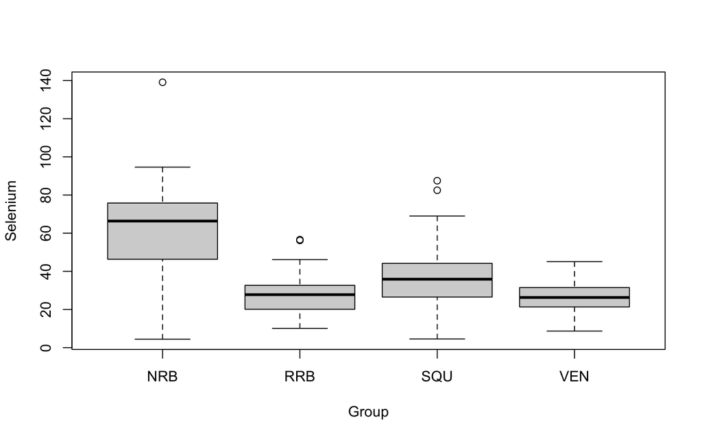

```r
boxplot(Selenium ~ Group, data = Exa8.2.1)
```

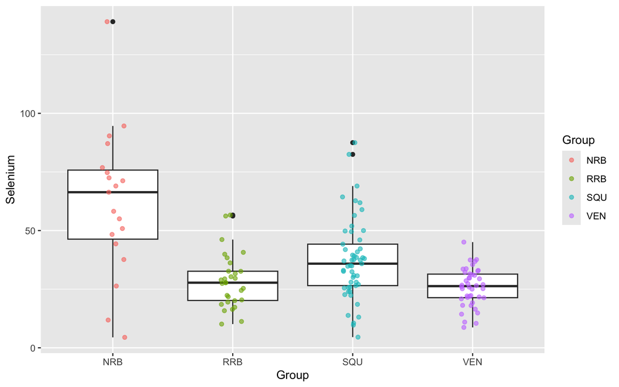

```r
#
ggplot(data = Exa8.2.1, aes(x = Group, y = Selenium)) + geom_boxplot() + geom_jitter(width = 0.1,
    alpha = 0.6, aes(color = Group))
```

```r
# one way ANOVA estimated as a lineas model
Exa8.2.1_lm <- lm(Selenium ~ Group, data = Exa8.2.1)
(anova_Exa8.2.1_lm <- anova(Exa8.2.1_lm))
```

```
Analysis of Variance Table

Response: Selenium
           Df Sum Sq Mean Sq F value    Pr(>F)
Group       3  18935  6311.7  22.614 5.345e-12 ***
Residuals 140  39074   279.1
---
Signif. codes:  0 '***' 0.001 '**' 0.01 '*' 0.05 '.' 0.1 ' ' 1
```

```r
#
Exa8.2.1_aov <- aov(Selenium ~ Group, data = Exa8.2.1)

#
summary(Exa8.2.1_aov)
```

```
             Df Sum Sq Mean Sq F value   Pr(>F)
Group         3  18935    6312   22.61 5.34e-12 ***
Residuals   140  39074     279
---
Signif. codes:  0 '***' 0.001 '**' 0.01 '*' 0.05 '.' 0.1 ' ' 1
```

```r
model.tables(Exa8.2.1_aov, type = "means")
```

```
Tables of means
Grand mean

35.44736

 Group
      NRB   RRB   SQU   VEN
    62.05 28.52 37.42 25.88
rep 19.00 30.00 53.00 42.00
```

```r
model.tables(Exa8.2.1_aov, type = "effects")
```

```
Tables of effects

 Group
     NRB    RRB   SQU    VEN
    26.6 -6.925  1.97 -9.572
rep 19.0 30.000 53.00 42.000
```

```r
#
TukeyHSD(Exa8.2.1_aov)
```

```
  Tukey multiple comparisons of means
    95% family-wise confidence level

Fit: aov(formula = Selenium ~ Group, data = Exa8.2.1)

$Group
              diff        lwr        upr     p adj
RRB-NRB -33.523982 -46.260203 -20.787762 0.0000000
SQU-NRB -24.629335 -36.244663 -13.014007 0.0000010
VEN-NRB -36.170840 -48.180851 -24.160828 0.0000000
SQU-RRB   8.894648  -1.030122  18.819418 0.0961032
VEN-RRB  -2.646857 -13.030768   7.737053 0.9108599
VEN-SQU -11.541505 -20.515363  -2.567647 0.0057777
```

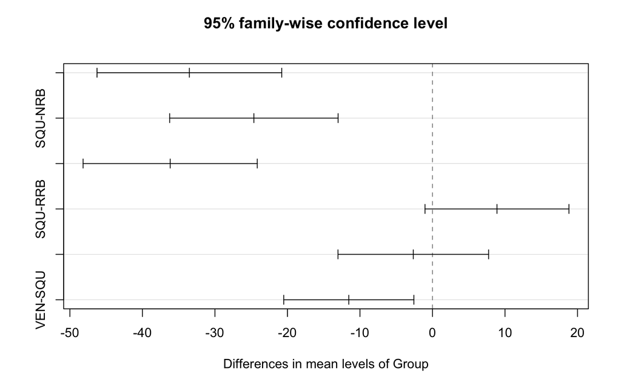

```r
plot(TukeyHSD(Exa8.2.1_aov))
```

**Más ejemplos**

Pacientes de enfermedades reumáticas u osteoporosis generalmente sufren de pérdidas críticas de densidad mineral osea (Bone Mineral Density, BMD). Un medicamento usado para recuperar o prevenir una pérdida mayor de BMD, es el Alendronato. Holcomb y Rothenberg examinaron a 96 mujeres tomando alendronato para determinar si había alguna diferencia en el promedio de cambio en densidad ósea entre cinco clasificaciones diagnostica primarias. El Grupo1 era de pacientes diagnosticados con artritis reumatoide (RA). Grupo2 era de pacientes con una variedad de diagnósticos incluyendo, Lupus, granulomatosis de Wegener y poliarteritis, y otros desordenes vasculares (LUPUS). Grupo3 consistió en pacientes diagnosticados con polimialgia reumática o artritis temporal (PMRTA). El Grupo4 estaba integrado por pacientes con artrosis (OA). Y el Grupo 5 de pacientes con diagnóstico de osteoporosis (O) sin otros desordenes reumáticos. ¿Puede determinar que los promedios de los grupos presentan alguna diferencia? Haga una gráfica de cajas de los grupos.

```r
# Exer. 8.2.2 Bone Mineral Density, BMD Patients suffering from rheumatic
# diseases or osteoporosis often suffer critical loss in bone mineral density
# (BMD).
EXR8.2.2 <- read_csv(file = "~/Dropbox/GitHub/ProbEstad/DataSets/ch08_all/EXR_C08_S02_02.csv",
    show_col_types = FALSE)
EXR8.2.2
```

```
# A tibble: 96 × 2
     BMD GROUP
   <dbl> <dbl>
 1 11.1      1
 2 24.4      1
 3 10.0      1
 4 -3.16     1
 5  6.84     1
 6  3.32     1
 7  1.49     1
 8 -1.86     1
 9  5.39     1
10  3.87     1
# ℹ 86 more rows
```

```r
EXR8.2.2$GROUP
```

```
 [1] 1 1 1 1 1 1 1 1 1 1 1 1 1 1 1 1 1 1 1 1 1 1 1 1 1 1 1 1 1 1 1 1 1 1 1 1 1 2
[39] 2 2 2 2 2 2 2 2 3 3 3 3 3 3 3 3 3 3 3 3 3 3 3 3 4 4 4 4 4 4 4 4 4 4 4 4 4 4
[77] 4 4 4 4 4 4 4 4 4
 [ reached 'max' / getOption("max.print") -- omitted 11 entries ]
```

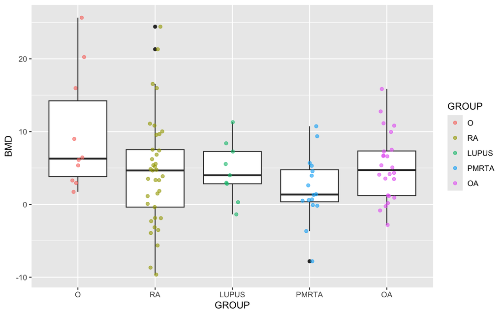

```r
EXR8.2.2_M <- EXR8.2.2 %>%
    mutate(GROUP = case_when(GROUP == 1 ~ "RA", GROUP == 2 ~ "LUPUS", GROUP == 3 ~
        "PMRTA", GROUP == 4 ~ "OA", GROUP == 5 ~ "O"))

EXR8.2.2_M <- EXR8.2.2_M %>%
    mutate(GROUP = GROUP %>%
        fct_relevel("O", "RA", "LUPUS", "PMRTA", "OA"))

EXR8.2.2_M %>%
    ggplot(aes(x = GROUP, y = BMD)) + geom_boxplot() + geom_jitter(width = 0.1, alpha = 0.6,
    aes(color = GROUP))
```

```r
#
Exr2_2.aov <- aov(BMD ~ GROUP, data = EXR8.2.2_M)

# anova() function to print the ANOVA table
anova(Exr2_2.aov)
```

```
Analysis of Variance Table

Response: BMD
          Df Sum Sq Mean Sq F value  Pr(>F)
GROUP      4  355.5  88.864  2.2772 0.06697 .
Residuals 91 3551.1  39.024
---
Signif. codes:  0 '***' 0.001 '**' 0.01 '*' 0.05 '.' 0.1 ' ' 1
```

```r
Exr2_2_lm <- lm(BMD ~ factor(GROUP), data = EXR8.2.2_M)
anova(Exr2_2_lm)
```

```
Analysis of Variance Table

Response: BMD
              Df Sum Sq Mean Sq F value  Pr(>F)
factor(GROUP)  4  355.5  88.864  2.2772 0.06697 .
Residuals     91 3551.1  39.024
---
Signif. codes:  0 '***' 0.001 '**' 0.01 '*' 0.05 '.' 0.1 ' ' 1
```

```r
# Using summary S() from car package. summary() can be used too.
S(Exr2_2_lm)
```

```
Call: lm(formula = BMD ~ factor(GROUP), data = EXR8.2.2_M)

Coefficients:
                   Estimate Std. Error t value Pr(>|t|)
(Intercept)           9.672      1.975   4.896 4.22e-06 ***
factor(GROUP)RA      -5.202      2.226  -2.336  0.02166 *
factor(GROUP)LUPUS   -5.094      2.870  -1.775  0.07929 .
factor(GROUP)PMRTA   -7.491      2.518  -2.975  0.00375 **
factor(GROUP)OA      -4.467      2.351  -1.900  0.06061 .
---
Signif. codes:  0 '***' 0.001 '**' 0.01 '*' 0.05 '.' 0.1 ' ' 1

Residual standard deviation: 6.247 on 91 degrees of freedom
Multiple R-squared: 0.09099
F-statistic: 2.277 on 4 and 91 DF,  p-value: 0.06697
   AIC    BIC
631.06 646.45
```

2. Ilich-Ernst y colaboradores estudiaron el consumo de calcio en la dieta de un grupo de 113 mujeres adultas sanas de edades entre 20 y 88 años. Los investigadores segregaron a los sujetos de estudio por grupos de edad de la siguiente manera: Grupo A; 20.0 – 45.9 años; grupo B; 46.00 – 55. 9 años; grupo C; 56.0 – 65.9 años; y grupo D; de más de 66 años. El consumo de calcio estuvo medido en mg/día. Los datos están listados en el archivo EXR_C08_S02_03.csv. Siguiendo un ANOVA, ¿se puede concluir que hay una diferencia en los promedios de las poblaciones? Haga un HSD Tukey para estimar las diferencias entre las distintas poblaciones, sea Alpha = .05. Grafique los datos usando una gráfica de cajas y explique los resultados.

```r
# # # # # # # # # # # # # # # # # # # # # # # # # # # # # # # # # # # # # Exr
# 8.2.3
Exr8.2.3 <- read_csv(file = "~/Dropbox/GitHub/ProbEstad/DataSets/ch08_all/EXR_C08_S02_03.csv",
    show_col_types = FALSE)
head(Exr8.2.3)
```

```
# A tibble: 6 × 2
  calcium Group
    <dbl> <chr>
1    1820 A
2    2588 A
3    2670 A
4    1022 A
5    1555 A
6     222 A
```

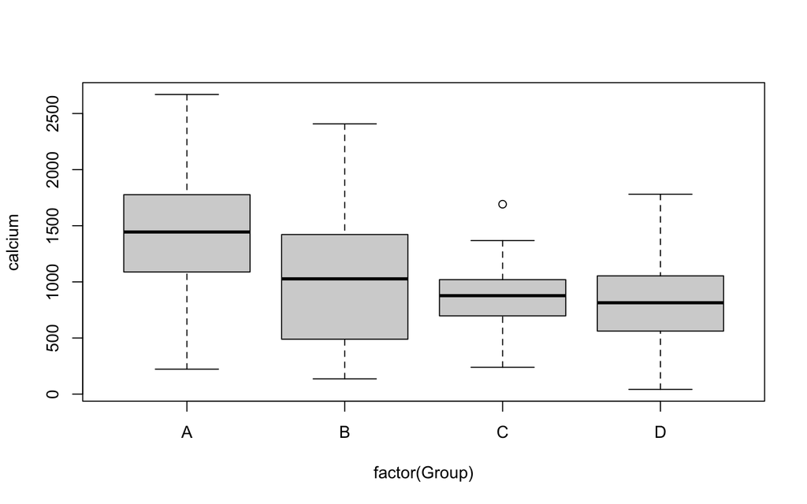

```r
plot(calcium ~ factor(Group), data = Exr8.2.3)
```

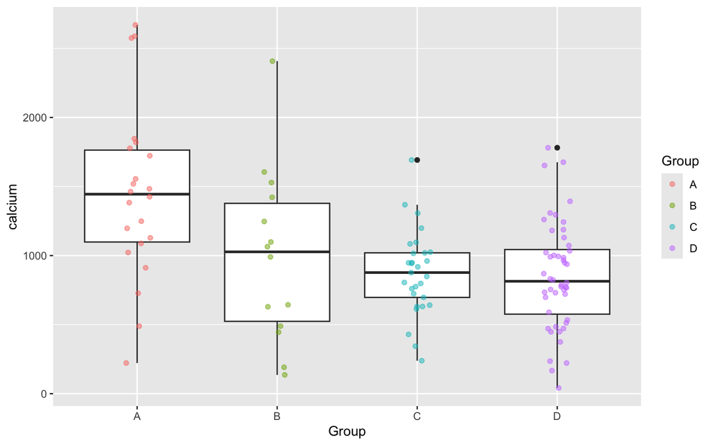

```r
ggplot(data = Exr8.2.3, aes(x = Group, y = calcium)) + geom_boxplot() + geom_jitter(width = 0.1,
    alpha = 0.5, aes(color = Group))
```

```r
Exr3.aov <- aov(calcium ~ Group, data = Exr8.2.3)
anova(Exr3.aov)
```

```
Analysis of Variance Table

Response: calcium
           Df   Sum Sq Mean Sq F value    Pr(>F)
Group       3  5931208 1977069  9.3588 1.476e-05 ***
Residuals 109 23026500  211252
---
Signif. codes:  0 '***' 0.001 '**' 0.01 '*' 0.05 '.' 0.1 ' ' 1
```

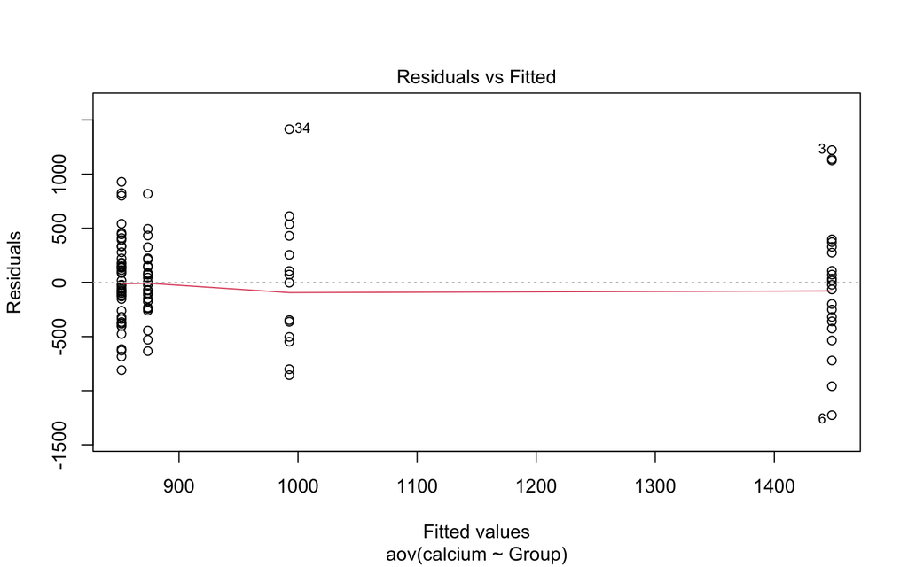

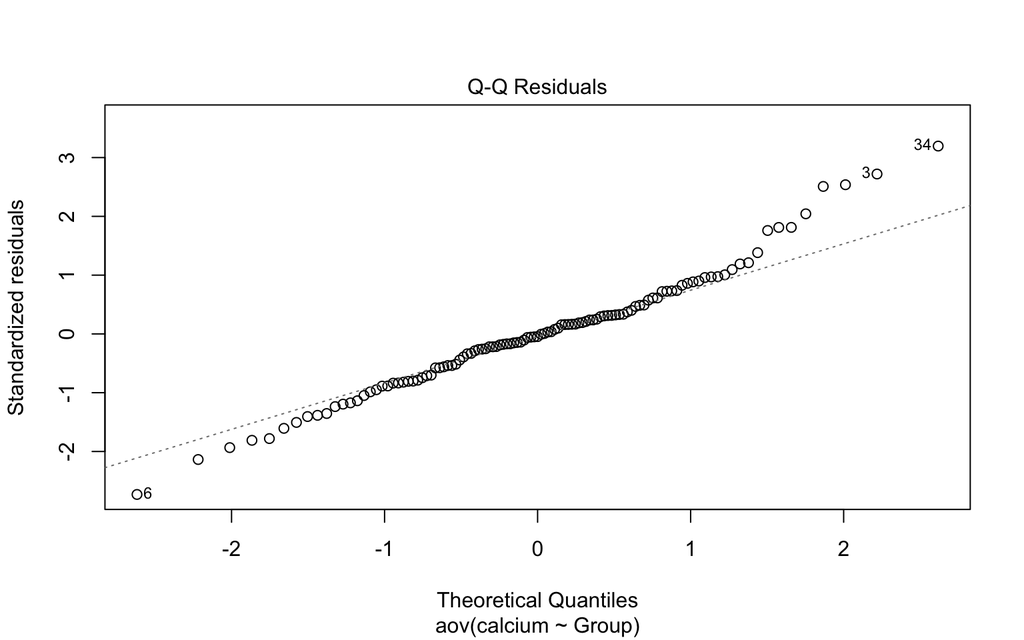

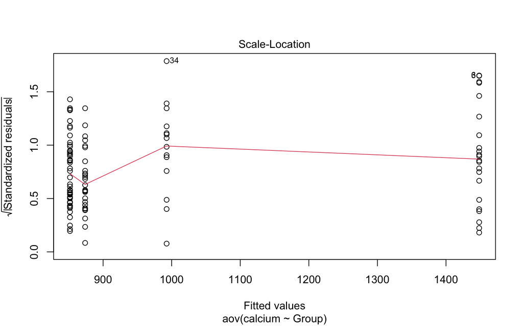

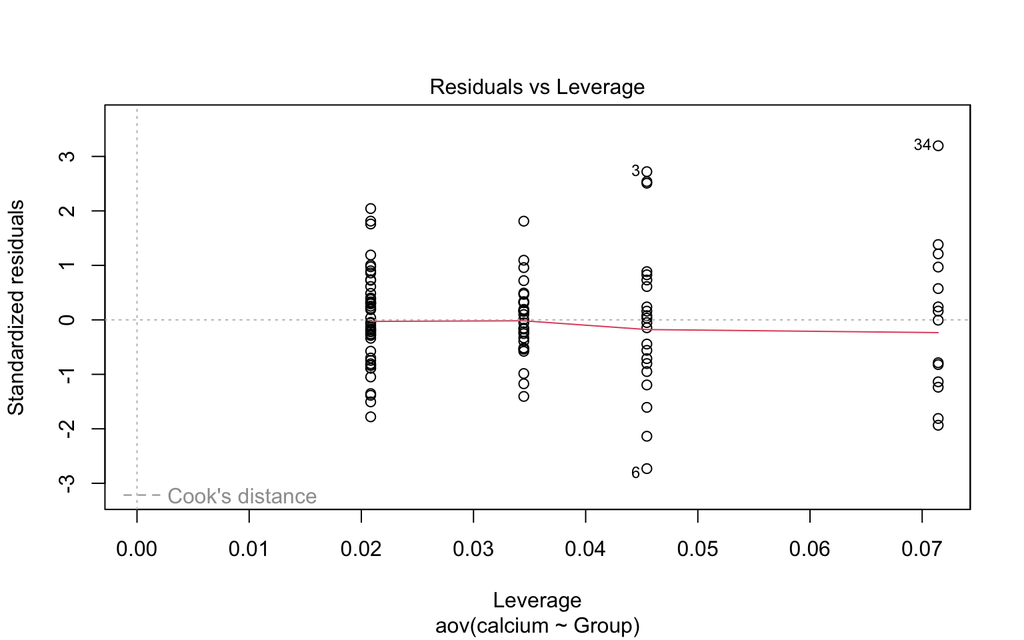

```r
plot(Exr3.aov)
```

```r
TukeyHSD(Exr3.aov)
```

```
  Tukey multiple comparisons of means
    95% family-wise confidence level

Fit: aov(formula = calcium ~ Group, data = Exr8.2.3)

$Group
          diff       lwr        upr     p adj
B-A -455.72078 -865.7066  -45.73492 0.0230454
C-A -574.53605 -913.5892 -235.48294 0.0001356
D-A -596.63447 -905.3867 -287.88228 0.0000109
C-B -118.81527 -509.0844  271.45386 0.8568796
D-B -140.91369 -505.1676  223.34020 0.7443051
D-C  -22.09842 -304.1436  259.94679 0.9969598
```

**emmeans** del inglés “Estimated Marginal Means” proporciona métodos para obtener *medias marginales estimadas* (EMMs, también conocidas como medias de mínimos cuadrados) En R la librería *emmeans* perminte calcular contrastes o combinaciones lineales de dichas medias marginales con varios ajustes por multiplicidad. También se pueden estimar y contrastar pendientes de líneas de tendencia.

```r
emmeans(Exr3.aov, pairwise ~ Group)
```

```
$emmeans
 Group emmean    SE  df lower.CL upper.CL
 A       1448  98.0 109     1254     1643
 B        993 123.0 109      749     1236
 C        874  85.3 109      705     1043
 D        852  66.3 109      720      983

Confidence level used: 0.95

$contrasts
 contrast estimate  SE  df t.ratio p.value
 A - B       455.7 157 109   2.900  0.0230
 A - C       574.5 130 109   4.421  0.0001
 A - D       596.6 118 109   5.042 <0.0001
 B - C       118.8 150 109   0.794  0.8569
 B - D       140.9 140 109   1.009  0.7443
 C - D        22.1 108 109   0.204  0.9970

P value adjustment: tukey method for comparing a family of 4 estimates
```

```r
emmeans(Exr3.aov, trt.vs.ctrl ~ Group)
```

```
$emmeans
 Group emmean    SE  df lower.CL upper.CL
 A       1448  98.0 109     1254     1643
 B        993 123.0 109      749     1236
 C        874  85.3 109      705     1043
 D        852  66.3 109      720      983

Confidence level used: 0.95

$contrasts
 contrast estimate  SE  df t.ratio p.value
 B - A        -456 157 109  -2.900  0.0128
 C - A        -575 130 109  -4.421 <0.0001
 D - A        -597 118 109  -5.042 <0.0001

P value adjustment: dunnettx method for 3 tests
```

```r
model.tables(Exr3.aov, type = "means", se = TRUE)
```

```
Tables of means
Grand mean

991.0177

 Group
       A     B     C     D
    1448 992.6 873.8 851.7
rep   22  14.0  29.0  48.0
```

```r
model.tables(Exr3.aov, type = "effects", se = TRUE)
```

```
Tables of effects

 Group
        A      B      C      D
    457.3  1.625 -117.2 -139.3
rep  22.0 14.000   29.0   48.0
```

## ANOVA de dos vías

Para el caso de un ANOVA de dos vías, tenemos que la función repuesta responde a dos factores que a su vez tiene dos o más niveles por factor: $Y \sim factor_1 + factor_2$. En este caso ya se puede presentar un término de interacción entre factores.

Del ejemplo 8.3.1 de Daniel para un ANOVA de dos vías: Un fisioterapeuta quería comparar tres métodos para enseñar a sus pacientes a usar una prótesis. Pensó que la proporción de aprendizage sería diferente dependiendo de la edad de los parcientes y desarrolló un experimento que le permitió tomar en cuenta la edad. Se construye la tabla de los datos del problema.

```r
# Build a table, index by index since Two-Way ANOVA EXAMPLE 8.3.1 has NO-data
# file, therefore we make the example table.

Learn <- tibble(Age = factor(rep(c(1, 2, 3, 4, 5), 3)), Method = factor(rep(1:3,
    c(5, 5, 5))), Rate = c(7, 8, 9, 10, 11, 9, 9, 9, 9, 12, 10, 10, 12, 12, 14))

Learn
```

```
# A tibble: 15 × 3
   Age   Method  Rate
   <fct> <fct>  <dbl>
 1 1     1          7
 2 2     1          8
 3 3     1          9
 4 4     1         10
 5 5     1         11
 6 1     2          9
 7 2     2          9
 8 3     2          9
 9 4     2          9
10 5     2         12
11 1     3         10
12 2     3         10
13 3     3         12
14 4     3         12
15 5     3         14
```

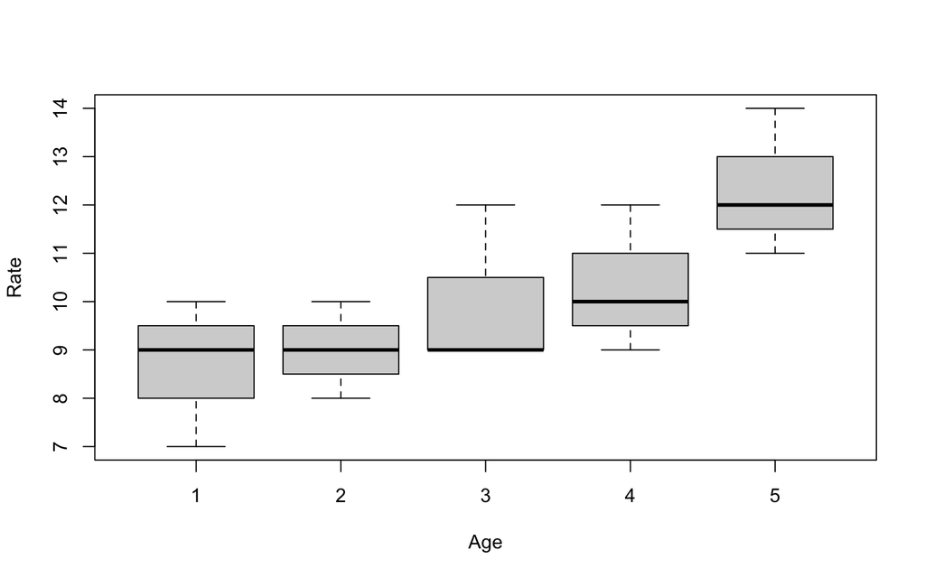

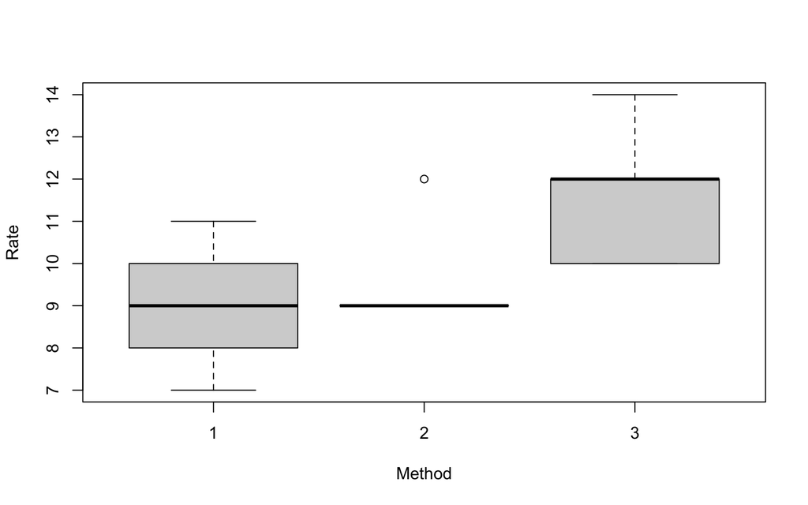

```r
#
plot(Rate ~ Age + Method, data = Learn)
```

Para las gráficas de cajas ejecutadas por un ggplot (o boxplot) es necesario mandar por separado cada grupo en la variable predictora (o independiente), o separar dos páneles, uno por cada grupo.

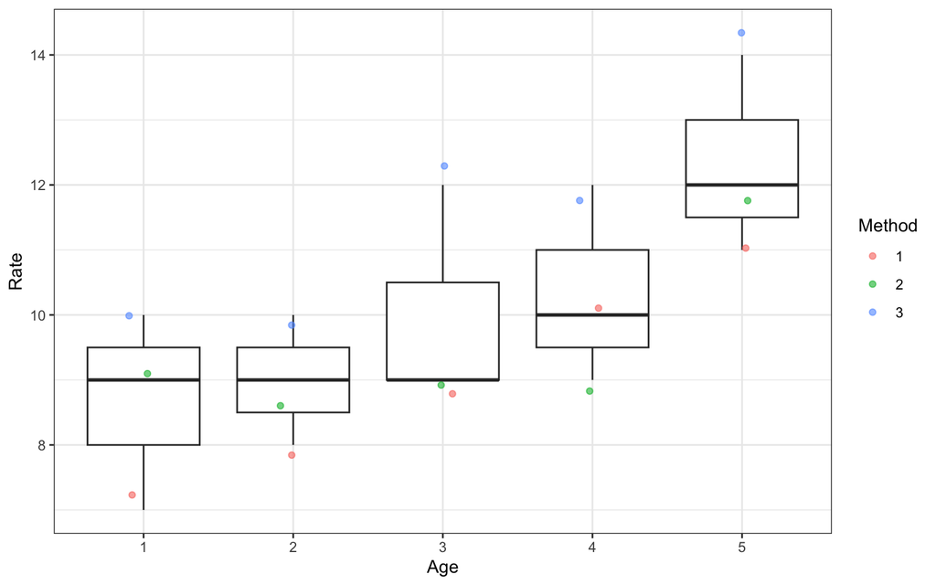

```r
# For the Age group

ggplot(data = Learn, aes(x = Age, y = Rate)) + geom_boxplot() + geom_jitter(width = 0.1,
    alpha = 0.6, aes(color = Method)) + theme_bw()
```

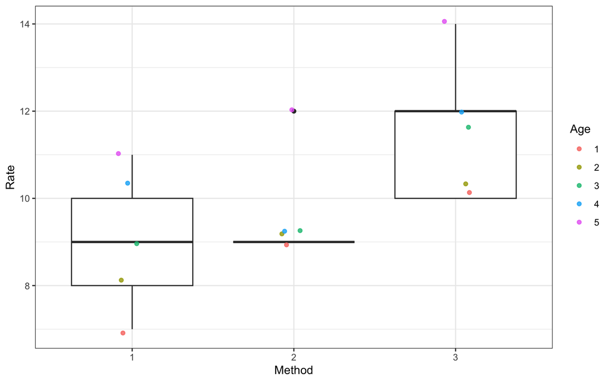

```r
# For the Rate group
ggplot(data = Learn, aes(x = Method, y = Rate)) + geom_boxplot() + geom_jitter(width = 0.1,
    alpha = 0.8, aes(color = Age)) + theme_bw()
```

```r
# now the ANOVA model
Rate_aov = aov(Rate ~ Method + Age, data = Learn)
anova(Rate_aov)
```

```
Analysis of Variance Table

Response: Rate
          Df  Sum Sq Mean Sq F value    Pr(>F)
Method     2 18.5333  9.2667  21.385 0.0006165 ***
Age        4 24.9333  6.2333  14.385 0.0010017 **
Residuals  8  3.4667  0.4333
---
Signif. codes:  0 '***' 0.001 '**' 0.01 '*' 0.05 '.' 0.1 ' ' 1
```

```r
layout(matrix(c(1, 2), nrow = 1, ncol = 2, byrow = TRUE))
TukeyHSD(Rate_aov)
```

```
  Tukey multiple comparisons of means
    95% family-wise confidence level

Fit: aov(formula = Rate ~ Method + Age, data = Learn)

$Method
    diff        lwr      upr     p adj
2-1  0.6 -0.5896489 1.789649 0.3666717
3-1  2.6  1.4103511 3.789649 0.0006358
3-2  2.0  0.8103511 3.189649 0.0034083

$Age
         diff        lwr      upr     p adj
2-1 0.3333333 -1.5235390 2.190206 0.9676094
3-1 1.3333333 -0.5235390 3.190206 0.1877558
4-1 1.6666667 -0.1902056 3.523539 0.0810838
5-1 3.6666667  1.8097944 5.523539 0.0009146
3-2 1.0000000 -0.8568723 2.856872 0.4057524
4-2 1.3333333 -0.5235390 3.190206 0.1877558
5-2 3.3333333  1.4764610 5.190206 0.0017351
4-3 0.3333333 -1.5235390 2.190206 0.9676094
5-3 2.3333333  0.4764610 4.190206 0.0154324
5-4 2.0000000  0.1431277 3.856872 0.0348816
```

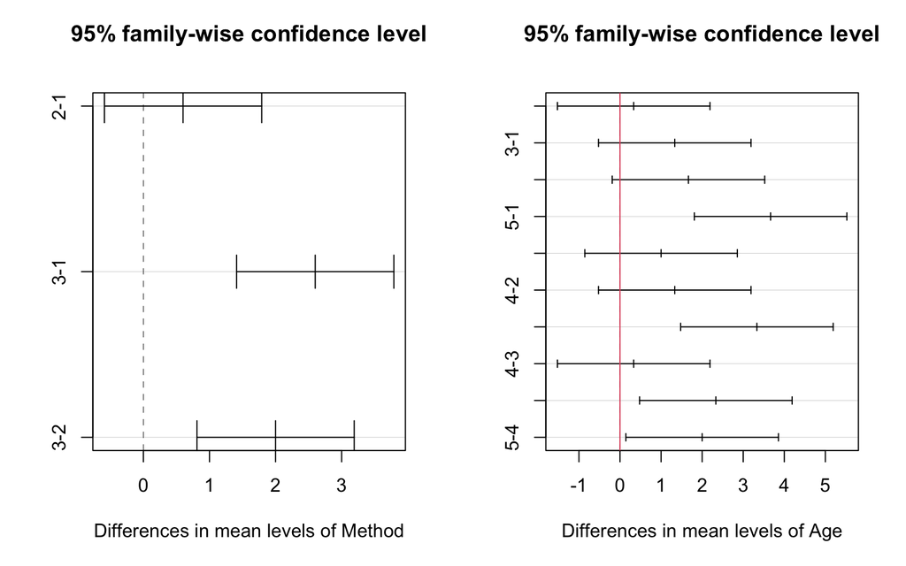

```r
plot(TukeyHSD(Rate_aov))
abline(v = 0, col = 2)
```

**Más Ejemplos de ANOVA de dos vías (two-way ANOVA)**

En un estudio de efectos pulmonares en conejillos de Indias, Lacroix et al. expuso a 18 conejillos de Indias sensibilizados y 18 no-sensibilizados con albúmina, a tres tratamientos distintos: aire regular, benzaldehido y acetildehido. Al final de la exposición los conejillos de Indias fueron anesteciados y la respuesta a alergias medida por lavado broncoalveolar (BAL). La tabla de resultados se muestra en REV_C08_16 y contiene la cuenta de células alveolares $(\times 10^6)$ por grupo de tratamiento (aire, benzaldehido y acetildehido) y sensibilizados o no con albúmina. Pruebe por las diferencias en a) entre sensibilizados y no sensibilizados por albúmina, b) entre los tres tratamientos. Sea $\alpha=.05$ en todas las pruebas.

```r
Rev8.16 <- read_csv("~/Dropbox/GitHub/ProbEstad/DataSets/ch08_all/REV_C08_16.csv",
    show_col_types = FALSE)

# how is the data ordered?
Rev8.16
```

```
# A tibble: 36 × 3
   Sens  Treat Count
   <chr> <chr> <dbl>
 1 No    Act    49.9
 2 No    Act    50.6
 3 No    Act    50.4
 4 No    Act    44.1
 5 No    Act    36.3
 6 No    Act    39.2
 7 No    Air    24.2
 8 No    Air    24.6
 9 No    Air    22.6
10 No    Air    25.1
# ℹ 26 more rows
```

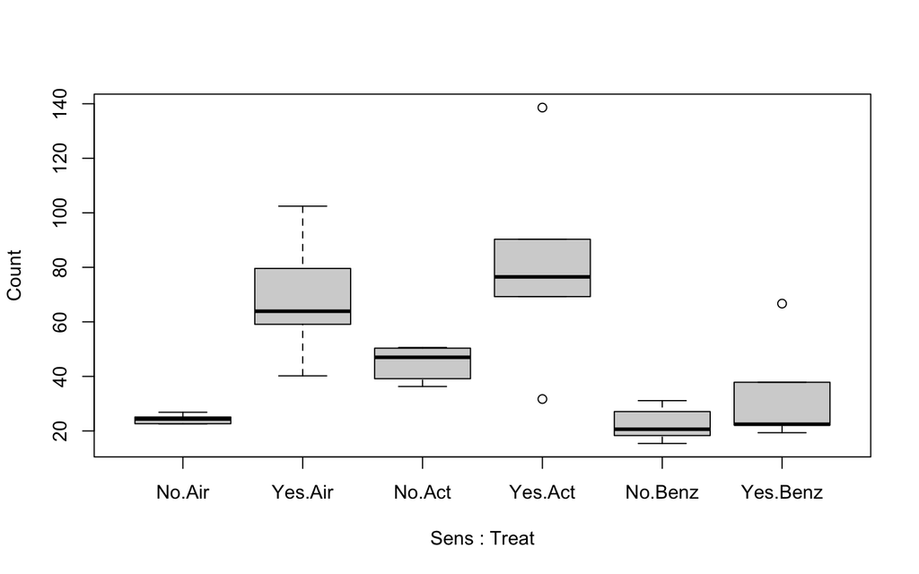

```r
Rev8.16_fac <- Rev8.16 %>%
    mutate(Sens = factor(Sens), Treat = factor(Treat))

Rev8.16_fac <- Rev8.16_fac %>%
    mutate(Treat = Treat %>%
        fct_relevel("Air", "Act", "Benz"))

boxplot(Count ~ Sens + Treat, data = Rev8.16_fac)
```

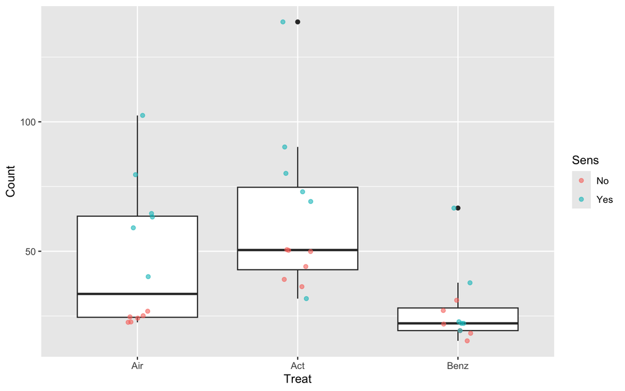

```r
ggplot(data = Rev8.16_fac, aes(x = Treat, y = Count)) + geom_boxplot() + geom_jitter(width = 0.1,
    alpha = 0.6, aes(color = Sens))
```

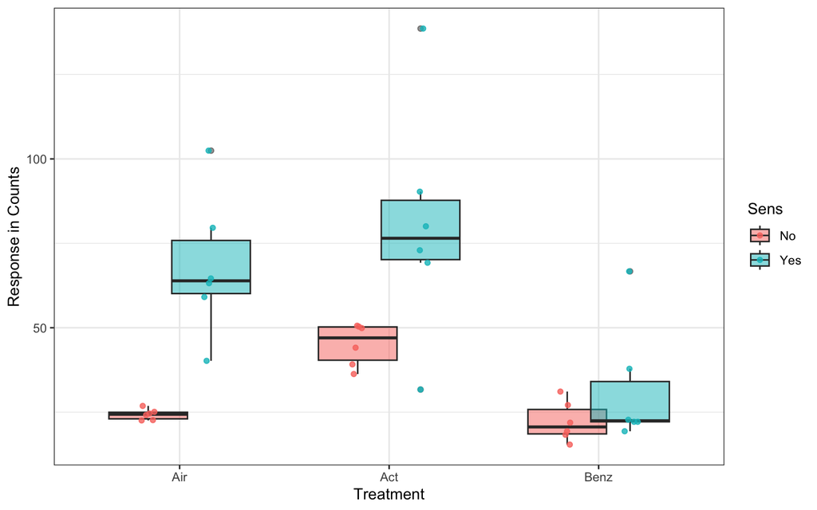

```r
ggplot(data = Rev8.16_fac, aes(x = Treat, y = Count, fill = Sens)) + geom_boxplot(position = position_dodge(width = 0.6),
    alpha = 0.5) + geom_jitter(position = position_jitterdodge(jitter.width = 0.15,
    dodge.width = 0.6), aes(color = Sens), alpha = 0.8, size = 1.4) + labs(x = "Treatment",
    y = "Response in Counts", fill = "Sens") + theme_bw()
```

```r
Rev8.16_aov <- aov(Count ~ Sens + Treat, data = Rev8.16_fac)
anova(Rev8.16_aov)
```

```
Analysis of Variance Table

Response: Count
          Df  Sum Sq Mean Sq F value    Pr(>F)
Sens       1  7906.2  7906.2  20.718 7.276e-05 ***
Treat      2  7688.6  3844.3  10.074 0.0004042 ***
Residuals 32 12211.5   381.6
---
Signif. codes:  0 '***' 0.001 '**' 0.01 '*' 0.05 '.' 0.1 ' ' 1
```

```r
# Listed with car Anova
Anova(Rev8.16_aov)
```

```
Anova Table (Type II tests)

Response: Count
           Sum Sq Df F value    Pr(>F)
Sens       7906.2  1  20.718 7.276e-05 ***
Treat      7688.6  2  10.074 0.0004042 ***
Residuals 12211.5 32
---
Signif. codes:  0 '***' 0.001 '**' 0.01 '*' 0.05 '.' 0.1 ' ' 1
```

```r
# Evaluation
anova(Rev8.16_aov)
```

```
Analysis of Variance Table

Response: Count
          Df  Sum Sq Mean Sq F value    Pr(>F)
Sens       1  7906.2  7906.2  20.718 7.276e-05 ***
Treat      2  7688.6  3844.3  10.074 0.0004042 ***
Residuals 32 12211.5   381.6
---
Signif. codes:  0 '***' 0.001 '**' 0.01 '*' 0.05 '.' 0.1 ' ' 1
```

```r
emmeans(Rev8.16_aov, pairwise ~ Sens + Treat)
```

```
$emmeans
 Sens Treat emmean   SE df lower.CL upper.CL
 No   Air     31.4 6.51 32    18.17     44.7
 Yes  Air     61.1 6.51 32    47.81     74.3
 No   Act     48.0 6.51 32    34.69     61.2
 Yes  Act     77.6 6.51 32    64.33     90.9
 No   Benz    12.2 6.51 32    -1.07     25.5
 Yes  Benz    41.8 6.51 32    28.56     55.1

Confidence level used: 0.95

$contrasts
 contrast           estimate    SE df t.ratio p.value
 No Air - Yes Air     -29.64  6.51 32  -4.552  0.0009
 No Air - No Act      -16.52  7.98 32  -2.071  0.3273
 No Air - Yes Act     -46.16 10.30 32  -4.483  0.0012
 No Air - No Benz      19.25  7.98 32   2.413  0.1820
 No Air - Yes Benz    -10.39 10.30 32  -1.009  0.9114
 Yes Air - No Act      13.12 10.30 32   1.275  0.7963
 Yes Air - Yes Act    -16.52  7.98 32  -2.071  0.3273
 Yes Air - No Benz     48.88 10.30 32   4.748  0.0005
 Yes Air - Yes Benz    19.25  7.98 32   2.413  0.1820
 No Act - Yes Act     -29.64  6.51 32  -4.552  0.0009
 No Act - No Benz      35.76  7.98 32   4.484  0.0011
 No Act - Yes Benz      6.12 10.30 32   0.595  0.9907
 Yes Act - No Benz     65.40 10.30 32   6.352 <0.0001
 Yes Act - Yes Benz    35.76  7.98 32   4.484  0.0011
 [ reached 'max' / getOption("max.print") -- omitted 1 row ]

P value adjustment: tukey method for comparing a family of 6 estimates
```

```r
emmeans(Rev8.16_aov, trt.vs.ctrl ~ Sens + Treat)
```

```
$emmeans
 Sens Treat emmean   SE df lower.CL upper.CL
 No   Air     31.4 6.51 32    18.17     44.7
 Yes  Air     61.1 6.51 32    47.81     74.3
 No   Act     48.0 6.51 32    34.69     61.2
 Yes  Act     77.6 6.51 32    64.33     90.9
 No   Benz    12.2 6.51 32    -1.07     25.5
 Yes  Benz    41.8 6.51 32    28.56     55.1

Confidence level used: 0.95

$contrasts
 contrast          estimate    SE df t.ratio p.value
 Yes Air - No Air      29.6  6.51 32   4.552  0.0003
 No Act - No Air       16.5  7.98 32   2.071  0.1723
 Yes Act - No Air      46.2 10.30 32   4.483  0.0004
 No Benz - No Air     -19.2  7.98 32  -2.413  0.0868
 Yes Benz - No Air     10.4 10.30 32   1.009  0.7331

P value adjustment: dunnettx method for 5 tests
```

```r
# With interactions
Rev8.16_lm_int <- aov(Count ~ Sens * Treat, data = Rev8.16_fac)
# model with interaction
anova(Rev8.16_lm_int)
```

```
Analysis of Variance Table

Response: Count
           Df  Sum Sq Mean Sq F value    Pr(>F)
Sens        1  7906.2  7906.2 23.0210 4.119e-05 ***
Treat       2  7688.6  3844.3 11.1938 0.0002336 ***
Sens:Treat  2  1908.5   954.3  2.7786 0.0781461 .
Residuals  30 10303.0   343.4
---
Signif. codes:  0 '***' 0.001 '**' 0.01 '*' 0.05 '.' 0.1 ' ' 1
```

```r
Rev8.16_lm_int_emm_p <- emmeans(Rev8.16_lm_int, pairwise ~ Sens + Treat)
Rev8.16_lm_int_emm_p
```

```
$emmeans
 Sens Treat emmean   SE df lower.CL upper.CL
 No   Air     24.3 7.57 30     8.87     39.8
 Yes  Air     68.2 7.57 30    52.74     83.6
 No   Act     45.1 7.57 30    29.62     60.5
 Yes  Act     80.5 7.57 30    65.02     95.9
 No   Benz    22.2 7.57 30     6.74     37.6
 Yes  Benz    31.8 7.57 30    16.37     47.3

Confidence level used: 0.95

$contrasts
 contrast           estimate   SE df t.ratio p.value
 No Air - Yes Air     -43.88 10.7 30  -4.101  0.0036
 No Air - No Act      -20.75 10.7 30  -1.939  0.3993
 No Air - Yes Act     -56.16 10.7 30  -5.249  0.0002
 No Air - No Benz       2.12 10.7 30   0.199  1.0000
 No Air - Yes Benz     -7.51 10.7 30  -0.702  0.9803
 Yes Air - No Act      23.12 10.7 30   2.161  0.2850
 Yes Air - Yes Act    -12.28 10.7 30  -1.148  0.8572
 Yes Air - No Benz     46.00 10.7 30   4.299  0.0021
 Yes Air - Yes Benz    36.37 10.7 30   3.399  0.0215
 No Act - Yes Act     -35.41 10.7 30  -3.309  0.0268
 No Act - No Benz      22.88 10.7 30   2.138  0.2959
 No Act - Yes Benz     13.24 10.7 30   1.238  0.8150
 Yes Act - No Benz     58.28 10.7 30   5.447 <0.0001
 Yes Act - Yes Benz    48.65 10.7 30   4.547  0.0011
 [ reached 'max' / getOption("max.print") -- omitted 1 row ]

P value adjustment: tukey method for comparing a family of 6 estimates
```

```r
Rev8.16_lm_int_emm_c <- emmeans(Rev8.16_lm_int, trt.vs.ctrl ~ Sens + Treat)
Rev8.16_lm_int_emm_c
```

```
$emmeans
 Sens Treat emmean   SE df lower.CL upper.CL
 No   Air     24.3 7.57 30     8.87     39.8
 Yes  Air     68.2 7.57 30    52.74     83.6
 No   Act     45.1 7.57 30    29.62     60.5
 Yes  Act     80.5 7.57 30    65.02     95.9
 No   Benz    22.2 7.57 30     6.74     37.6
 Yes  Benz    31.8 7.57 30    16.37     47.3

Confidence level used: 0.95

$contrasts
 contrast          estimate   SE df t.ratio p.value
 Yes Air - No Air     43.88 10.7 30   4.101  0.0013
 No Act - No Air      20.75 10.7 30   1.939  0.2205
 Yes Act - No Air     56.16 10.7 30   5.249 <0.0001
 No Benz - No Air     -2.12 10.7 30  -0.199  0.9958
 Yes Benz - No Air     7.51 10.7 30   0.702  0.8862

P value adjustment: dunnettx method for 5 tests
```

**Otro Ejemplo** El interés del estudio de Hartman-Maeir et al. fue estimar los perfiles del déficit de concienciación entre pacientes con infarto cerebral que están en rehabilitación. Estudió 35 pacientes con lesiones por infarto en el hemisferio derecho y 19 pacientes con lesiones en el hemisferio izquierdo. Además agrupó las lesiones por su tamaño como: 2 = 1-3 cm, 3 = 3-5cm, y 4 = 5 cm o más grandes. Una de las medidas importantes fue la calificación de la concienciación por su propia limitación. Las calificaciones tuvieron un rango de 8 a 24, con una calificación más alta significando mayor concienciación (REV_C08_22.csv). Pruebe la diferencia por tamaño de lesión y lado de hemisferio, sea $\alpha = .05$.

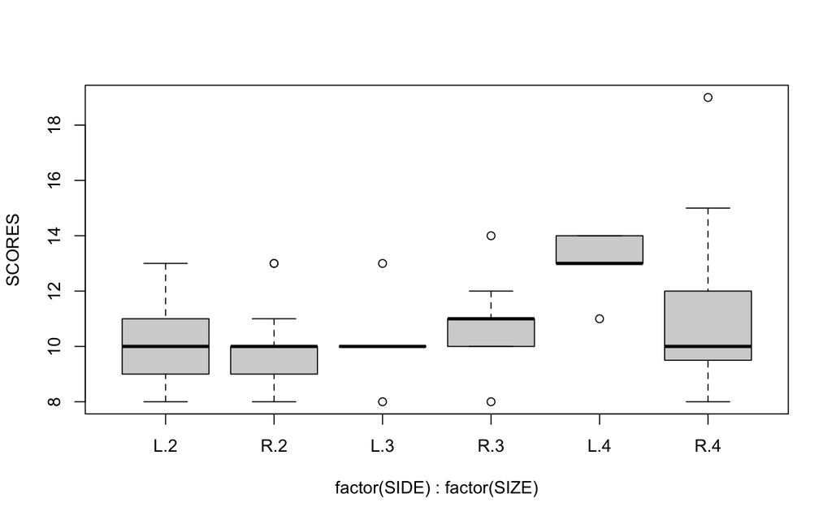

```r
Rev.8.22 <- read_csv("~/Dropbox/GitHub/ProbEstad/DataSets/ch08_all/REV_C08_22.csv",
    show_col_types = FALSE)

boxplot(SCORES ~ factor(SIDE) + factor(SIZE), data = Rev.8.22)
```

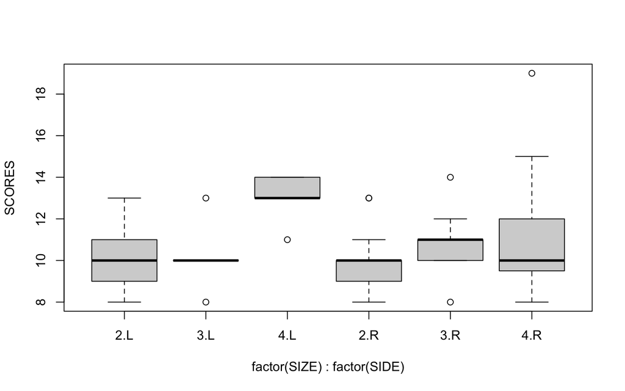

```r
boxplot(SCORES ~ factor(SIZE) + factor(SIDE), data = Rev.8.22)
```

```r
#
Rev.8.22_lm <- aov(SCORES ~ factor(SIZE) + factor(SIDE), data = Rev.8.22)
anova(Rev.8.22_lm)
```

```
Analysis of Variance Table

Response: SCORES
             Df  Sum Sq Mean Sq F value  Pr(>F)
factor(SIZE)  2  28.690 14.3451  3.5094 0.03748 *
factor(SIDE)  1   2.578  2.5782  0.6307 0.43084
Residuals    50 204.380  4.0876
---
Signif. codes:  0 '***' 0.001 '**' 0.01 '*' 0.05 '.' 0.1 ' ' 1
```

```r
# contrasts
emmeans(Rev.8.22_lm, pairwise ~ SIDE)
```

```
$emmeans
 SIDE emmean    SE df lower.CL upper.CL
 L      11.1 0.470 50    10.11     12.0
 R      10.6 0.345 50     9.91     11.3

Results are averaged over the levels of: SIZE
Confidence level used: 0.95

$contrasts
 contrast estimate    SE df t.ratio p.value
 L - R       0.459 0.578 50   0.794  0.4308

Results are averaged over the levels of: SIZE
```

```r
Rev.8.22_lm_int <- lm(SCORES ~ factor(SIZE) * factor(SIDE), data = Rev.8.22)
Anova(Rev.8.22_lm_int)
```

```
Anova Table (Type II tests)

Response: SCORES
                           Sum Sq Df F value Pr(>F)
factor(SIZE)               29.981  2  3.7121 0.0317 *
factor(SIDE)                2.578  1  0.6384 0.4282
factor(SIZE):factor(SIDE)  10.540  2  1.3050 0.2806
Residuals                 193.840 48
---
Signif. codes:  0 '***' 0.001 '**' 0.01 '*' 0.05 '.' 0.1 ' ' 1
```

```r
#
emmeans(Rev.8.22_lm_int, trt.vs.ctrl ~ SIZE)
```

```
$emmeans
 SIZE emmean    SE df lower.CL upper.CL
    2   10.0 0.429 48     9.16     10.9
    3   10.5 0.560 48     9.36     11.6
    4   12.1 0.535 48    11.01     13.2

Results are averaged over the levels of: SIDE
Confidence level used: 0.95

$contrasts
 contrast      estimate    SE df t.ratio p.value
 SIZE3 - SIZE2    0.469 0.706 48   0.664  0.7243
 SIZE4 - SIZE2    2.063 0.686 48   3.009  0.0081

Results are averaged over the levels of: SIDE
P value adjustment: dunnettx method for 2 tests
```

```r
# emmip(Rev.8.22_lm_int, SIDE ~ SIZE)

# With rstatix
Rev.8.22_aov <- anova_test(data = Rev.8.22, SCORES ~ factor(SIZE) * factor(SIDE))
get_anova_table(Rev.8.22_aov)
```

```
ANOVA Table (type II tests)

                     Effect DFn DFd     F     p p<.05   ges
1              factor(SIZE)   2  48 3.712 0.032     * 0.134
2              factor(SIDE)   1  48 0.638 0.428       0.013
3 factor(SIZE):factor(SIDE)   2  48 1.305 0.281       0.052
```

```r
# Post hoc
emmeans_test(Rev.8.22, SCORES ~ SIZE, p.adjust.method = "fdr")
```

```
# A tibble: 3 × 9
  term  .y.    group1 group2    df statistic      p  p.adj p.adj.signif
* <chr> <chr>  <chr>  <chr>  <dbl>     <dbl>  <dbl>  <dbl> <chr>
1 SIZE  SCORES 2      3         51    -0.837 0.407  0.407  ns
2 SIZE  SCORES 2      4         51    -2.65  0.0108 0.0323 *
3 SIZE  SCORES 3      4         51    -1.56  0.125  0.187  ns
```

**Ejemplo 18** Los efectos de la contaminación térmica sobre Corbicula fluminea (almejas asiáticas) en tres ubicaciones geográficas diferentes fueron analizados por John Brooker (REV_C08_18). Los datos muestrales sobre la longitud, el ancho y la altura de las conchas se presentan en la siguiente tabla. Determine si existe una diferencia significativa en la longitud, altura o ancho medios (medidos en mm) de la concha en las tres ubicaciones, realizando tres análisis. ¿Qué inferencias pueden extraerse de sus resultados? ¿Cuáles son los supuestos subyacentes a dichas inferencias? ¿Cuáles son las poblaciones objetivo?

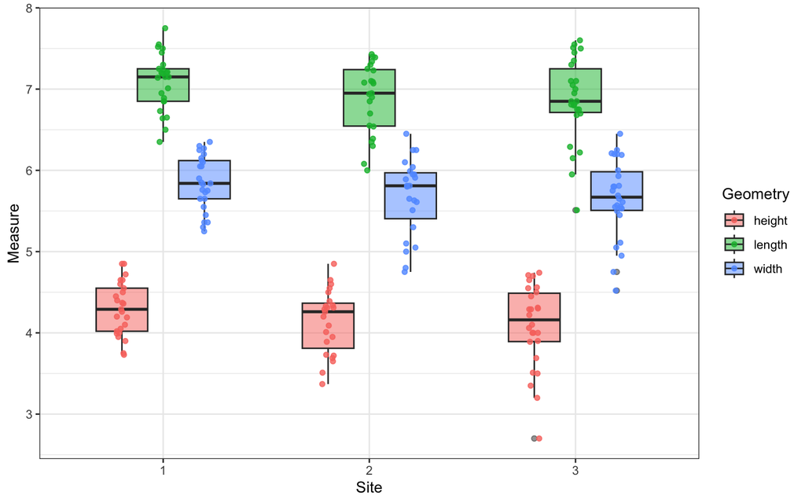

```r
Rev.8.18 <- read_csv("~/Dropbox/GitHub/ProbEstad/DataSets/ch08_all/REV_C08_18_mod.csv",
    show_col_types = FALSE)

Rev.8.18 <- Rev.8.18 %>%
    mutate(Geometry = factor(Geometry))
Rev.8.18 <- Rev.8.18 %>%
    mutate(site = factor(site))

ggplot(data = Rev.8.18, aes(x = site, y = Measure, fill = Geometry)) + geom_boxplot(position = position_dodge(width = 0.6),
    alpha = 0.5) + geom_jitter(position = position_jitterdodge(jitter.width = 0.15,
    dodge.width = 0.6), aes(color = Geometry), alpha = 0.8, size = 1.4) + labs(x = "Site",
    y = "Measure", fill = "Geometry") + theme_bw()
```

```r
#
Rev.8.18_lm <- lm(Measure ~ factor(site) * factor(Geometry), data = Rev.8.18)
Anova(Rev.8.18_lm)
```

```
Anova Table (Type II tests)

Response: Measure
                               Sum Sq  Df  F value    Pr(>F)
factor(site)                    1.869   2   4.9802  0.007694 **
factor(Geometry)              286.132   2 762.5696 < 2.2e-16 ***
factor(site):factor(Geometry)   0.027   4   0.0355  0.997576
Residuals                      39.961 213
---
Signif. codes:  0 '***' 0.001 '**' 0.01 '*' 0.05 '.' 0.1 ' ' 1
```

```r
# Pairwise post hoc options('max.print' = 10000)
emmeans(Rev.8.18_lm, trt.vs.ctrl ~ site)
```

```
$emmeans
 site emmean     SE  df lower.CL upper.CL
 1      5.74 0.0500 213     5.64     5.84
 2      5.57 0.0521 213     5.46     5.67
 3      5.54 0.0490 213     5.44     5.63

Results are averaged over the levels of: Geometry
Confidence level used: 0.95

$contrasts
 contrast      estimate     SE  df t.ratio p.value
 site2 - site1   -0.177 0.0723 213  -2.446  0.0293
 site3 - site1   -0.206 0.0700 213  -2.942  0.0071

Results are averaged over the levels of: Geometry
P value adjustment: dunnettx method for 2 tests
```

## ANOVA Modelos de medidas repetidas

Los modelos de medidas repetidas son aquellos en los que la misma variable es medida en los mismos sujetos en dos o más ocasiones. En donde cada ocasión puede significar una condición distinta; como diferentes tratamientos o diferentes puntos de tiempo.  
Las ventajas de usar este tipo de modelos se han mencionado y son que permiten controlar variables relacionadas con el sujeto y con factores relacionados con el estudio que se está desarrollado .

**Ejemplo** Licciardone et al. examinaron sujetos con dolor lumbar crónico inespecífico. En este estudio, 18 de los sujetos completaron un cuestionario de encuesta que evaluaba el funcionamiento físico al inicio, y después de 1, 3 y 6 meses. La Tabla (EXA_C08_S04_01) muestra los datos de estos sujetos que recibieron un tratamiento simulado que parecía ser una manipulación osteopática genuina. Valores más altos indican un mejor funcionamiento físico. El objetivo del experimento fue determinar si los sujetos reportarían mejoría con el tiempo, aun cuando el tratamiento recibido proporcionaría una mejoría mínima. Deseamos saber si existe una diferencia en los valores medios de la encuesta entre los cuatro puntos en el tiempo.

```r
Exa8.4.1 <- read_csv("~/Dropbox/GitHub/ProbEstad/DataSets/ch08_all/EXA_C08_S04_01mod.csv",
    show_col_types = FALSE)
Exa8.4.1 <- Exa8.4.1 %>%
    mutate(Subject = factor(Subject), Time = factor(Time))

head(Exa8.4.1, 26)
```

```
# A tibble: 26 × 3
   Assessment Time     Subject
        <dbl> <fct>    <fct>
 1         80 Baseline 1
 2         95 Baseline 2
 3         65 Baseline 3
 4         50 Baseline 4
 5         60 Baseline 5
 6         70 Baseline 6
 7         80 Baseline 7
 8         70 Baseline 8
 9         80 Baseline 9
10         65 Baseline 10
# ℹ 16 more rows
```

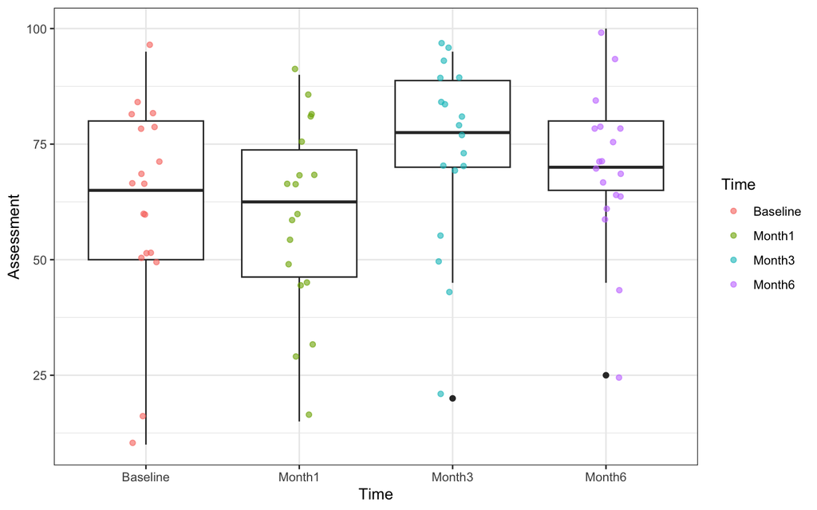

```r
ggplot(data = Exa8.4.1, aes(x = Time, y = Assessment)) + geom_boxplot() + geom_jitter(width = 0.1,
    alpha = 0.6, aes(color = Time)) + theme_bw()
```

```r
# Find outliers (extreme if present)
Exa8.4.1 %>%
    group_by(Time) %>%
    identify_outliers(Assessment)
```

```
# A tibble: 2 × 5
  Time   Assessment Subject is.outlier is.extreme
  <fct>       <dbl> <fct>   <lgl>      <lgl>
1 Month3         20 16      TRUE       FALSE
2 Month6         25 16      TRUE       FALSE
```

```r
# Test normal distribution
Exa8.4.1 %>%
    group_by(Time) %>%
    shapiro_test(Assessment)
```

```
# A tibble: 4 × 4
  Time     variable   statistic      p
  <fct>    <chr>          <dbl>  <dbl>
1 Baseline Assessment     0.900 0.0568
2 Month1   Assessment     0.960 0.611
3 Month3   Assessment     0.884 0.0303
4 Month6   Assessment     0.935 0.235
```

```r
# # # # # # # # # # # # # # # # # # # With the R basic anova function, how to
# make a repeated measures
Exa8.4.1_mod <- aov(Assessment ~ Time + Error(Subject), data = Exa8.4.1)
summary(Exa8.4.1_mod)
```

```
Error: Subject
          Df Sum Sq Mean Sq F value Pr(>F)
Residuals 17  20238    1190

Error: Within
          Df Sum Sq Mean Sq F value  Pr(>F)
Time       3   2396   798.6   5.501 0.00237 **
Residuals 51   7404   145.2
---
Signif. codes:  0 '***' 0.001 '**' 0.01 '*' 0.05 '.' 0.1 ' ' 1
```

```r
emmeans(Exa8.4.1_mod, pairwise ~ Time)
```

```
$emmeans
 Time     emmean   SE   df lower.CL upper.CL
 Baseline   61.9 4.75 30.4     52.2     71.6
 Month1     59.4 4.75 30.4     49.7     69.1
 Month3     73.6 4.75 30.4     63.9     83.3
 Month6     70.0 4.75 30.4     60.3     79.7

Warning: EMMs are biased unless design is perfectly balanced
Confidence level used: 0.95

$contrasts
 contrast          estimate   SE df t.ratio p.value
 Baseline - Month1     2.50 4.02 51   0.622  0.9244
 Baseline - Month3   -11.67 4.02 51  -2.905  0.0269
 Baseline - Month6    -8.06 4.02 51  -2.006  0.1994
 Month1 - Month3     -14.17 4.02 51  -3.527  0.0048
 Month1 - Month6     -10.56 4.02 51  -2.628  0.0534
 Month3 - Month6       3.61 4.02 51   0.899  0.8053

P value adjustment: tukey method for comparing a family of 4 estimates
```

Ejemplo 2. Polyzogopoulou et al. reportan los efectos de la cirugía bariátrica sobre los niveles de glucosa en ayuno (mmol/L) en 12 sujetos obesos con diabetestipo 2 en cuatro momentos: antes de la operación, a los 3 meses, 6 meses y 12 meses. ¿Podemos concluir, tras eliminar los efectos atribuibles a los sujetos, que los niveles de glucosa en ayuno difieren a lo largo del tiempo después de la cirugía? Considere $\alpha = 0.05$.

```r
Exr8.32 <- read_csv("~/Dropbox/GitHub/ProbEstad/DataSets/ch08_all/REV_C08_32.csv",
    show_col_types = FALSE)
Exr8.32
```

```
# A tibble: 48 × 3
    SUBJ GLUCOSE  TIME
   <dbl>   <dbl> <dbl>
 1     1   108       0
 2     2    96.7     0
 3     3    77       0
 4     4    92       0
 5     5    97       0
 6     6    94       0
 7     7    76       0
 8     8   100       0
 9     9    82       0
10    10   104.      0
# ℹ 38 more rows
```

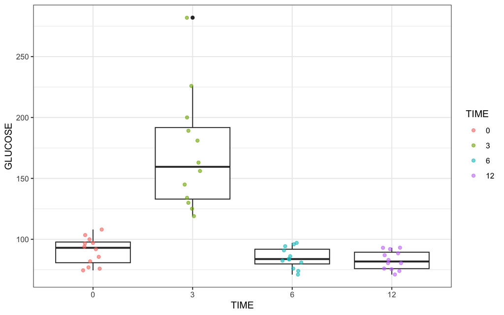

```r
Exr8.32 <- Exr8.32 %>%
    mutate(SUBJ = factor(SUBJ), TIME = factor(TIME))

ggplot(data = Exr8.32, aes(x = TIME, y = GLUCOSE)) + geom_boxplot() + geom_jitter(width = 0.1,
    alpha = 0.6, aes(color = TIME)) + theme_bw()
```

```r
# Find outliers (extreme if present)
Exr8.32 %>%
    group_by(TIME) %>%
    identify_outliers(GLUCOSE)
```

```
# A tibble: 1 × 5
  TIME  SUBJ  GLUCOSE is.outlier is.extreme
  <fct> <fct>   <dbl> <lgl>      <lgl>
1 3     9         282 TRUE       FALSE
```

```r
# Test normal distribution
Exr8.32 %>%
    group_by(TIME) %>%
    shapiro_test(GLUCOSE)
```

```
# A tibble: 4 × 4
  TIME  variable statistic     p
  <fct> <chr>        <dbl> <dbl>
1 0     GLUCOSE      0.940 0.497
2 3     GLUCOSE      0.902 0.169
3 6     GLUCOSE      0.951 0.652
4 12    GLUCOSE      0.925 0.334
```

```r
Exr8.32_mod <- aov(GLUCOSE ~ TIME + Error(SUBJ), data = Exr8.32)
summary(Exr8.32_mod)
```

```
Error: SUBJ
          Df Sum Sq Mean Sq F value Pr(>F)
Residuals 11  10517   956.1

Error: Within
          Df Sum Sq Mean Sq F value   Pr(>F)
TIME       3  65135   21712   40.22 3.98e-11 ***
Residuals 33  17816     540
---
Signif. codes:  0 '***' 0.001 '**' 0.01 '*' 0.05 '.' 0.1 ' ' 1
```

```r
emmeans(Exr8.32_mod, pairwise ~ TIME)
```

```
$emmeans
 TIME emmean   SE   df lower.CL upper.CL
 0      90.5 7.33 40.8     75.7    105.3
 3     170.8 7.33 40.8    156.0    185.6
 6      84.7 7.33 40.8     69.9     99.5
 12     82.8 7.33 40.8     68.0     97.6

Warning: EMMs are biased unless design is perfectly balanced
Confidence level used: 0.95

$contrasts
 contrast       estimate   SE df t.ratio p.value
 TIME0 - TIME3    -80.32 9.49 33  -8.467 <0.0001
 TIME0 - TIME6      5.83 9.49 33   0.614  0.9269
 TIME0 - TIME12     7.68 9.49 33   0.810  0.8493
 TIME3 - TIME6     86.14 9.49 33   9.081 <0.0001
 TIME3 - TIME12    88.00 9.49 33   9.277 <0.0001
 TIME6 - TIME12     1.86 9.49 33   0.196  0.9973

P value adjustment: tukey method for comparing a family of 4 estimates
```

```r
emmeans(Exr8.32_mod, trt.vs.ctrl ~ TIME)
```

```
$emmeans
 TIME emmean   SE   df lower.CL upper.CL
 0      90.5 7.33 40.8     75.7    105.3
 3     170.8 7.33 40.8    156.0    185.6
 6      84.7 7.33 40.8     69.9     99.5
 12     82.8 7.33 40.8     68.0     97.6

Warning: EMMs are biased unless design is perfectly balanced
Confidence level used: 0.95

$contrasts
 contrast       estimate   SE df t.ratio p.value
 TIME3 - TIME0     80.32 9.49 33   8.467 <0.0001
 TIME6 - TIME0     -5.83 9.49 33  -0.614  0.8439
 TIME12 - TIME0    -7.68 9.49 33  -0.810  0.7359

P value adjustment: dunnettx method for 3 tests
```

Hay un par de librerias de R - rstatix y ggpubr - que redefinen varias de las puebas de “base R” y de ggplot para estructuras tibble. En esta sección usamos algunas de estas funciones que en ocaciones hacen más fácil la definición del problema y el uso de los datos en tibble.

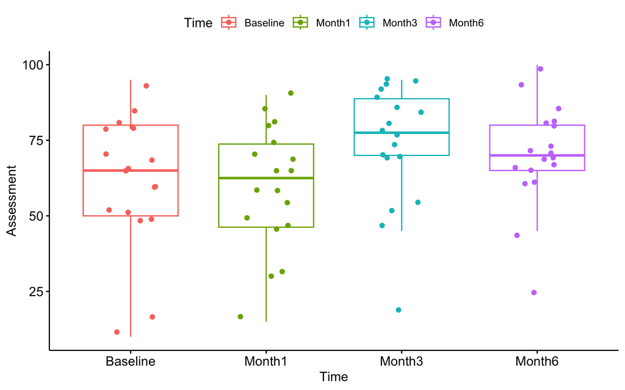

```r
# ggplot used with ggpubr package
bxp <- ggboxplot(data = Exa8.4.1, x = "Time", y = "Assessment", add = "jitter", color = "Time")
bxp
```

```r
# ANOVA test from the rstatix package
Exa8.4.1_aov <- anova_test(data = Exa8.4.1, dv = Assessment, wid = Subject, within = Time)
get_anova_table(Exa8.4.1_aov)
```

```
ANOVA Table (type III tests)

  Effect  DFn   DFd     F     p p<.05  ges
1   Time 2.22 37.68 5.501 0.006     * 0.08
```

```r
# Pairwise comparisons
emmeans_test(Exa8.4.1, Assessment ~ Time, p.adjust.method = "bonferroni")
```

```
# A tibble: 6 × 9
  term  .y.        group1   group2    df statistic      p p.adj p.adj.signif
* <chr> <chr>      <chr>    <chr>  <dbl>     <dbl>  <dbl> <dbl> <chr>
1 Time  Assessment Baseline Month1    68     0.372 0.711  1     ns
2 Time  Assessment Baseline Month3    68    -1.74  0.0871 0.523 ns
3 Time  Assessment Baseline Month6    68    -1.20  0.235  1     ns
4 Time  Assessment Month1   Month3    68    -2.11  0.0387 0.232 ns
5 Time  Assessment Month1   Month6    68    -1.57  0.121  0.725 ns
6 Time  Assessment Month3   Month6    68     0.537 0.593  1     ns
```

```r
# Pairwise comparisons
pwc <- Exa8.4.1 %>%
    pairwise_t_test(Assessment ~ Time, paired = TRUE, p.adjust.method = "bonferroni")
pwc
```

```
# A tibble: 6 × 10
  .y.        group1  group2    n1    n2 statistic    df     p p.adj p.adj.signif
* <chr>      <chr>   <chr>  <int> <int>     <dbl> <dbl> <dbl> <dbl> <chr>
1 Assessment Baseli… Month1    18    18     0.658    17 0.519 1     ns
2 Assessment Baseli… Month3    18    18    -2.72     17 0.015 0.088 ns
3 Assessment Baseli… Month6    18    18    -1.75     17 0.099 0.592 ns
4 Assessment Month1  Month3    18    18    -3.86     17 0.001 0.007 **
5 Assessment Month1  Month6    18    18    -2.22     17 0.04  0.24  ns
6 Assessment Month3  Month6    18    18     1.40     17 0.18  1     ns
```